# Prosper Loan Data Exploration

## Introduction

This notebook investigates a dataset containing loan information of approximately 113,000 loan entries from Prosper Funding LLC.

## Preliminary Wrangling

```python
# import all packages and set plots to be embedded inline
import numpy as np
import pandas as pd
import matplotlib.pyplot as plt
import seaborn as sns

%matplotlib inline
```

```python
# load in the dataset into a pandas dataframe, print statistics
df_loan = pd.read_csv("prosperLoanData.csv")
```

```python
# Overview of data structure and properties
df_loan.head(5)
```

|  | ListingKey | ListingNumber | ListingCreationDate | CreditGrade | Term | LoanStatus | ClosedDate | BorrowerAPR | BorrowerRate | LenderYield | ... | LP_ServiceFees | LP_CollectionFees | LP_GrossPrincipalLoss | LP_NetPrincipalLoss | LP_NonPrincipalRecoverypayments | PercentFunded | Recommendations | InvestmentFromFriendsCount | InvestmentFromFriendsAmount | Investors |
| --- | --- | --- | --- | --- | --- | --- | --- | --- | --- | --- | --- | --- | --- | --- | --- | --- | --- | --- | --- | --- | --- |
| 0 | 1021339766868145413AB3B | 193129 | 2007-08-26 19:09:29.263000000 | C | 36 | Completed | 2009-08-14 00:00:00 | 0.16516 | 0.1580 | 0.1380 | ... | -133.18 | 0.0 | 0.0 | 0.0 | 0.0 | 1.0 | 0 | 0 | 0.0 | 258 |
| 1 | 10273602499503308B223C1 | 1209647 | 2014-02-27 08:28:07.900000000 | NaN | 36 | Current | NaN | 0.12016 | 0.0920 | 0.0820 | ... | 0.00 | 0.0 | 0.0 | 0.0 | 0.0 | 1.0 | 0 | 0 | 0.0 | 1 |
| 2 | 0EE9337825851032864889A | 81716 | 2007-01-05 15:00:47.090000000 | HR | 36 | Completed | 2009-12-17 00:00:00 | 0.28269 | 0.2750 | 0.2400 | ... | -24.20 | 0.0 | 0.0 | 0.0 | 0.0 | 1.0 | 0 | 0 | 0.0 | 41 |
| 3 | 0EF5356002482715299901A | 658116 | 2012-10-22 11:02:35.010000000 | NaN | 36 | Current | NaN | 0.12528 | 0.0974 | 0.0874 | ... | -108.01 | 0.0 | 0.0 | 0.0 | 0.0 | 1.0 | 0 | 0 | 0.0 | 158 |
| 4 | 0F023589499656230C5E3E2 | 909464 | 2013-09-14 18:38:39.097000000 | NaN | 36 | Current | NaN | 0.24614 | 0.2085 | 0.1985 | ... | -60.27 | 0.0 | 0.0 | 0.0 | 0.0 | 1.0 | 0 | 0 | 0.0 | 20 |

5 rows × 81 columns

```python
df_loan.shape
```

```
(113937, 81)
```

```python
df_loan.info()
```

```
<class 'pandas.core.frame.DataFrame'>
RangeIndex: 113937 entries, 0 to 113936
Data columns (total 81 columns):
 #   Column                               Non-Null Count   Dtype
---  ------                               --------------   -----
 0   ListingKey                           113937 non-null  object
 1   ListingNumber                        113937 non-null  int64
 2   ListingCreationDate                  113937 non-null  object
 3   CreditGrade                          28953 non-null   object
 4   Term                                 113937 non-null  int64
 5   LoanStatus                           113937 non-null  object
 6   ClosedDate                           55089 non-null   object
 7   BorrowerAPR                          113912 non-null  float64
 8   BorrowerRate                         113937 non-null  float64
 9   LenderYield                          113937 non-null  float64
```

[output cut: 73 more lines]

```python
df_loan.describe()
```

|  | ListingNumber | Term | BorrowerAPR | BorrowerRate | LenderYield | EstimatedEffectiveYield | EstimatedLoss | EstimatedReturn | ProsperRating (numeric) | ProsperScore | ... | LP_ServiceFees | LP_CollectionFees | LP_GrossPrincipalLoss | LP_NetPrincipalLoss | LP_NonPrincipalRecoverypayments | PercentFunded | Recommendations | InvestmentFromFriendsCount | InvestmentFromFriendsAmount | Investors |
| --- | --- | --- | --- | --- | --- | --- | --- | --- | --- | --- | --- | --- | --- | --- | --- | --- | --- | --- | --- | --- | --- |
| count | 1.139370e+05 | 113937.000000 | 113912.000000 | 113937.000000 | 113937.000000 | 84853.000000 | 84853.000000 | 84853.000000 | 84853.000000 | 84853.000000 | ... | 113937.000000 | 113937.000000 | 113937.000000 | 113937.000000 | 113937.000000 | 113937.000000 | 113937.000000 | 113937.000000 | 113937.000000 | 113937.000000 |
| mean | 6.278857e+05 | 40.830248 | 0.218828 | 0.192764 | 0.182701 | 0.168661 | 0.080306 | 0.096068 | 4.072243 | 5.950067 | ... | -54.725641 | -14.242698 | 700.446342 | 681.420499 | 25.142686 | 0.998584 | 0.048027 | 0.023460 | 16.550751 | 80.475228 |
| std | 3.280762e+05 | 10.436212 | 0.080364 | 0.074818 | 0.074516 | 0.068467 | 0.046764 | 0.030403 | 1.673227 | 2.376501 | ... | 60.675425 | 109.232758 | 2388.513831 | 2357.167068 | 275.657937 | 0.017919 | 0.332353 | 0.232412 | 294.545422 | 103.239020 |
| min | 4.000000e+00 | 12.000000 | 0.006530 | 0.000000 | -0.010000 | -0.182700 | 0.004900 | -0.182700 | 1.000000 | 1.000000 | ... | -664.870000 | -9274.750000 | -94.200000 | -954.550000 | 0.000000 | 0.700000 | 0.000000 | 0.000000 | 0.000000 | 1.000000 |
| 25% | 4.009190e+05 | 36.000000 | 0.156290 | 0.134000 | 0.124200 | 0.115670 | 0.042400 | 0.074080 | 3.000000 | 4.000000 | ... | -73.180000 | 0.000000 | 0.000000 | 0.000000 | 0.000000 | 1.000000 | 0.000000 | 0.000000 | 0.000000 | 2.000000 |
| 50% | 6.005540e+05 | 36.000000 | 0.209760 | 0.184000 | 0.173000 | 0.161500 | 0.072400 | 0.091700 | 4.000000 | 6.000000 | ... | -34.440000 | 0.000000 | 0.000000 | 0.000000 | 0.000000 | 1.000000 | 0.000000 | 0.000000 | 0.000000 | 44.000000 |
| 75% | 8.926340e+05 | 36.000000 | 0.283810 | 0.250000 | 0.240000 | 0.224300 | 0.112000 | 0.116600 | 5.000000 | 8.000000 | ... | -13.920000 | 0.000000 | 0.000000 | 0.000000 | 0.000000 | 1.000000 | 0.000000 | 0.000000 | 0.000000 | 115.000000 |
| max | 1.255725e+06 | 60.000000 | 0.512290 | 0.497500 | 0.492500 | 0.319900 | 0.366000 | 0.283700 | 7.000000 | 11.000000 | ... | 32.060000 | 0.000000 | 25000.000000 | 25000.000000 | 21117.900000 | 1.012500 | 39.000000 | 33.000000 | 25000.000000 | 1189.000000 |

8 rows × 61 columns

### What is the structure of your dataset?

There are 113,937 loan entries in the dataset with 81 features (some of the features are LoanOriginalAmount, Term, BorrowerAPR, EmploymentStatus, IsBorrowerHomeowner, StatedMonthlyIncome, IncomeRange, MonthlyLoanPayment). Most of the variables are numeric in nature, and others are either of categorical or string data type.

### What is/are the main feature(s) of interest in your dataset?

I'm most interested in figuring out what features are best for predicting the borrower's Monthly Loan Payment for the loan.

### What features in the dataset do you think will help support your investigation into your feature(s) of interest?

With so many features to consider, I believe that the LoanOriginalAmount, Term, and StatedMonthlyIncome will have a strong effect on the Borrower's Monthly Loan Payment: The higher the LoanOriginalAmount, the higher the MonthlyLoanPayment; An increase in the Loan Term will reduce the MonthlyLoanPayment and also the higher the StatedMonthlyIncome the higher the MonthlyLoanPayment. I also suspect that other features like BorrowerAPR, EmploymentStatus, IncomeRange, and Investors, will have effects on the MonthlyLoanPayment, though not as much as the Term, LoanOriginalAmount and StatedMonthlyIncome.

## Univariate Exploration

I'll start by looking at the distribution of the main variable of interest: Monthly Loan Payment.

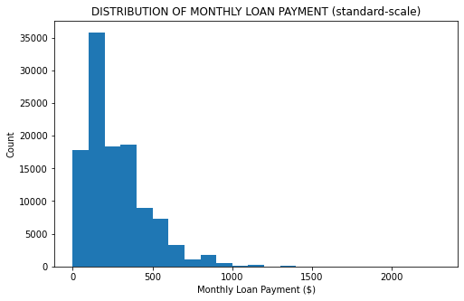

```python
# start with a standard-scaled plot
binsize = 100
bins = np.arange(0, df_loan["MonthlyLoanPayment"].max()+binsize, binsize)

plt.figure(figsize=[8, 5])
plt.hist(data = df_loan, x = "MonthlyLoanPayment", bins = bins)
plt.xlabel('Monthly Loan Payment ($)')
plt.ylabel('Count')
plt.title("DISTRIBUTION OF MONTHLY LOAN PAYMENT (standard-scale)")
plt.show()
```

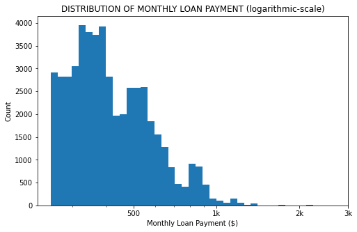

```python
# there's a long tail in the distribution, so let's put it on a log scale instead
log_binsize = 0.025
bins = 10 ** np.arange(2.4, np.log10(df_loan["MonthlyLoanPayment"].max())+log_binsize, log_binsize)

plt.figure(figsize=[8, 5])
plt.hist(data = df_loan, x = "MonthlyLoanPayment", bins = bins)
plt.xscale('log')
plt.xticks([500, 1e3, 2e3, 3e3], [500, '1k', '2k', '3k'])
plt.xlabel('Monthly Loan Payment ($)')
plt.ylabel('Count')
plt.title("DISTRIBUTION OF MONTHLY LOAN PAYMENT (logarithmic-scale)")
plt.show()
```

MonthlyLoanPayment has a long-tailed distribution and we find that a bulk of the entries are below $500. When plotted on a log-scale, the MonthlyLoanPayment distribution is skewed to the right.

#### Next up, the first predictor variable of interest: LoanOriginalAmount

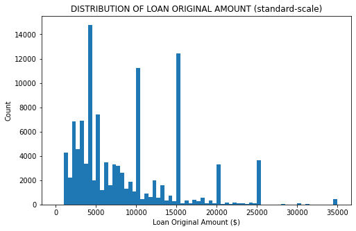

```python
# plotting LoanOriginalAmount on a standard scale
binsize = 500
bins = np.arange(0, df_loan['LoanOriginalAmount'].max()+binsize, binsize)

plt.figure(figsize=[8, 5])
plt.hist(data = df_loan, x = 'LoanOriginalAmount', bins = bins)
plt.xlabel('Loan Original Amount ($)')
plt.ylabel('Count')
plt.title("DISTRIBUTION OF LOAN ORIGINAL AMOUNT (standard-scale)")
plt.show()
```

The LoanOriginalAmount shows very large spikes in the frequency mostly at bars representing nearest thousand. With this We can assume that majority of the loans taken where whole (rounded) thousands (e.g. 5k, 10k, 15k, 20k, 25k).

#### Here, I look at other predictor variables of interest: Term and Employment Status

Look at distributions of Loan-Term and Employment Status

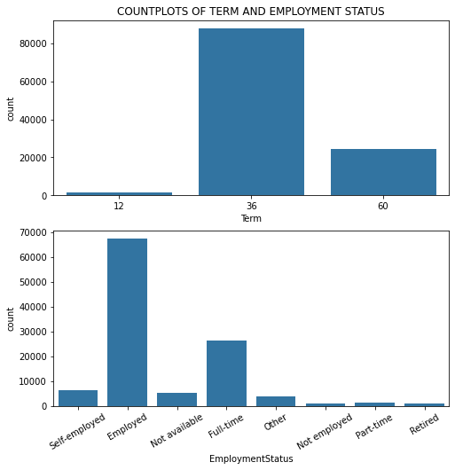

```python
fig, ax = plt.subplots(nrows=2, figsize = [8,8])
base_color = sns.color_palette()[0]
sns.countplot(data = df_loan, x = 'Term', color = base_color, ax = ax[0]).set(title = 'COUNTPLOTS OF TERM AND EMPLOYMENT STATUS');
sns.countplot(data = df_loan, x = 'EmploymentStatus', color = base_color, ax = ax[1]);
plt.xticks(rotation=30);
```

A large number of the loans taken had term lengths of 36 months, followed by those with term lenghts of 60 months and lastly a small portion of the loans had terms of 12 months. Also, most of the Borrower's are Employed, this could suggest that they are more likely to apply and be granted loans.

#### Stated Monthly Income

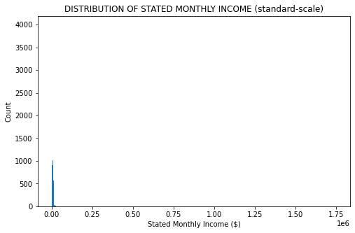

```python
# plotting StatedMonthlyIncome on a standard scale
binsize = 100
bins = np.arange(0, df_loan['StatedMonthlyIncome'].max()+binsize, binsize)

plt.figure(figsize=[8, 5])
plt.hist(data = df_loan, x = 'StatedMonthlyIncome', bins = bins)
plt.xlabel('Stated Monthly Income ($)')
plt.ylabel('Count')
plt.title("DISTRIBUTION OF STATED MONTHLY INCOME (standard-scale)")
plt.show()
```

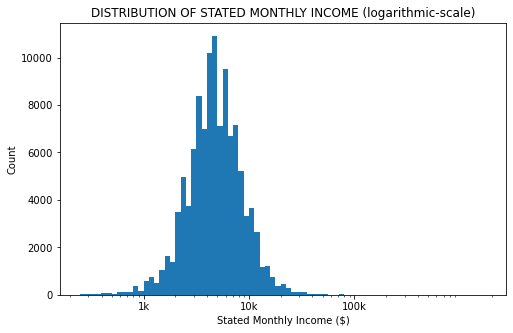

```python
# there's a long tail in the distribution, so let's put it on a log scale instead
log_binsize = 0.05
bins = 10 ** np.arange(2.4, np.log10(df_loan["StatedMonthlyIncome"].max())+log_binsize, log_binsize)

plt.figure(figsize=[8, 5])
plt.hist(data = df_loan, x = "StatedMonthlyIncome", bins = bins)
plt.xscale('log')
plt.xticks([1e3, 1e4, 1e5], ['1k', '10k', '100k'])
plt.xlabel('Stated Monthly Income ($)')
plt.ylabel('Count')
plt.title("DISTRIBUTION OF STATED MONTHLY INCOME (logarithmic-scale)")
plt.show()
```

The StatedMonthlyIncome is unimodal and the distribution is a little narrower than a normal distribution.

#### BorrowerAPR

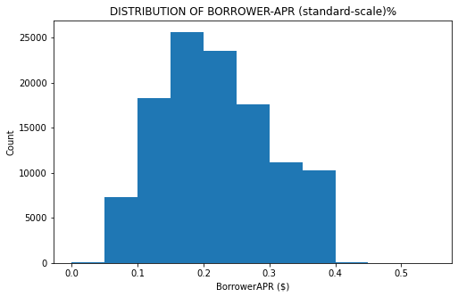

```python
# plotting BorrowerAPR on a standard scale
binsize = 0.05
bins = np.arange(0, df_loan['BorrowerAPR'].max()+binsize, binsize)

plt.figure(figsize=[8, 5])
plt.hist(data = df_loan, x = 'BorrowerAPR', bins = bins)
plt.xlabel('BorrowerAPR ($)');
plt.ylabel('Count')
plt.title("DISTRIBUTION OF BORROWER-APR (standard-scale)%");
```

### Investors

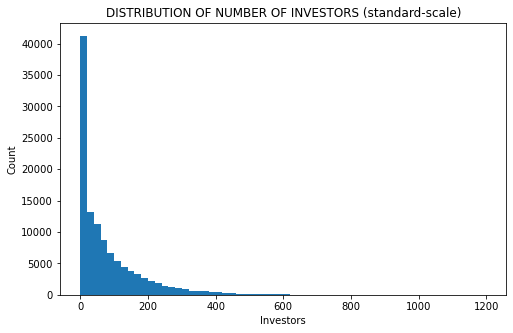

```python
# plotting Investors on a standard scale
binsize = 20
bins = np.arange(0, df_loan['Investors'].max()+binsize, binsize)

plt.figure(figsize=[8, 5])
plt.hist(data = df_loan, x = 'Investors', bins = bins)
plt.xlabel('Investors');
plt.ylabel('Count')
plt.title("DISTRIBUTION OF NUMBER OF INVESTORS (standard-scale)");
```

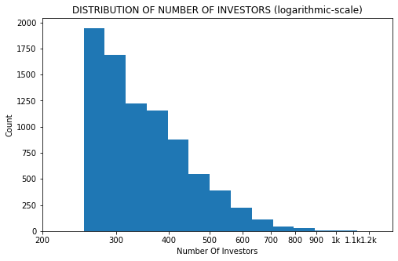

```python
# there's a long tail in the distribution, so let's put it on a log scale instead
log_binsize = 0.05
bins = 10 ** np.arange(2.4, np.log10(df_loan['Investors'].max())+log_binsize, log_binsize)

plt.figure(figsize=[8, 5])
plt.hist(data = df_loan, x = 'Investors', bins = bins)
plt.xscale('log')
plt.xticks([200, 300, 400, 500, 600, 700, 800, 900, 1000, 1100, 1200], ['200', '300', '400', '500', '600', '700', '800', '900', '1k', '1.1k', '1.2k'])
plt.xlabel('Number Of Investors')
plt.ylabel('Count')
plt.title("DISTRIBUTION OF NUMBER OF INVESTORS (logarithmic-scale)")
plt.show()
```

Investors has a long-tailed distribution, with a lot of Borrower's Loans having very small number of Investors. I decided to plot it on a log-scale, the distribution is Right skewed.

### Another predictor variable of Interrest: Income Range

```python
df_loan.IncomeRange.value_counts()
```

```
$25,000-49,999    32192
$50,000-74,999    31050
$100,000+         17337
$75,000-99,999    16916
Not displayed      7741
$1-24,999          7274
Not employed        806
$0                  621
Name: IncomeRange, dtype: int64
```

```python
#combine "Not employed", "Not sdisplayed" and "$0" Income ranges together

df_loan['IncomeRange'].replace(['Not employed', 'Not displayed'], '$0', inplace = True)
```

```python
# create ordinal categories for income
ordinal_rating = ['$100,000+', '$75,000-99,999', '$50,000-74,999', '$25,000-49,999', '$1-24,999', '$0']
ordered_var = pd.api.types.CategoricalDtype(ordered = True, categories = ordinal_rating)
df_loan['IncomeRange'] = df_loan['IncomeRange'].astype(ordered_var)
```

[figure not shown]

```python
# bar chart
plt.figure(figsize = [8, 5])
base_color = sns.color_palette()[0]
sns.countplot(data = df_loan, y = 'IncomeRange', color = base_color)
plt.ylabel('Income Range')
plt.xlabel('Count')
plt.title('DISTRIBUTION OF BORROWER INCOMES');
```

Most of the Borrower's earn salaries/incomes within the range of \$ 25000 - $49999 and also the income range $50000 - $74999

### Discuss the distribution(s) of your variable(s) of interest. Were there any unusual points? Did you need to perform any transformations?

The MonthlyLoanPayment variable had a large range of values and thus produced a long-tailed distribution, so i looked at the data using a log transform. Under the log transformation, the data skewed to the right, with most of the values around and between $500.

### Of the features you investigated, were there any unusual distributions? Did you perform any operations on the data to tidy, adjust, or change the form of the data? If so, why did you do this?

On further investigation into the predictor variables, the StatedMonthlyIncome was misleading when plotted on a standard scale, so a log transformation was used and it produced a unimodal distribution. A log transformation was also used to plot the Investors variable as the standard scale produced a long-tailed distribution. I decided to tidy the IncomeRange variable by combining 'Not employed', 'Not displayed' values to '$0' in the dataset.

## Bivariate Exploration

For my bivariate exploration, I will be looking at the pairwise correlations between selected features of interest in the data.

```python
num_vars = ["MonthlyLoanPayment","LoanOriginalAmount", "StatedMonthlyIncome", "BorrowerAPR", "Investors"]
cat_vars = ["Term", "EmploymentStatus", "IncomeRange"]
```

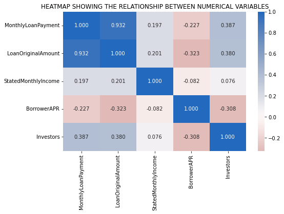

```python
# correlation plot
plt.figure(figsize = [8, 5])
sns.heatmap(df_loan[num_vars].corr(), annot = True, fmt = '.3f',
           cmap = 'vlag_r', center = 0)
plt.title('HEATMAP SHOWING THE RELATIONSHIP BETWEEN NUMERICAL VARIABLES')
plt.show()
```

```
df_loan.shape= (113937, 81)
loan_samp.shape= (500, 81)
```

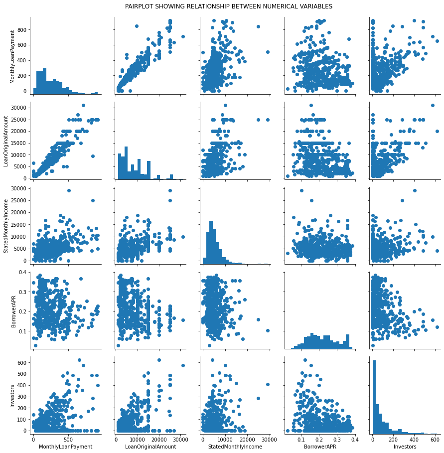

```python
# plot matrix: sample 500 diamonds so that plots are clearer and they render faster
print("df_loan.shape=",df_loan.shape)
loan_samp = df_loan.sample(n=500, replace = False)
print("loan_samp.shape=",loan_samp.shape)

g = sns.PairGrid(data = loan_samp, vars = num_vars)
g = g.map_diag(plt.hist, bins = 20);
g.map_offdiag(plt.scatter)
g.fig.suptitle("PAIRPLOT SHOWING RELATIONSHIP BETWEEN NUMERICAL VARIABLES", y=1.01);
```

From the above visualisations, it can be seen that the MonthlyLoanPayment and LoanOriginalAmount are highly correlated with each other which is expected.

It was expected that the StatedMonthlyIncome would be highly correlated with both the MonthlyLoanPayment and LoanOriginalAmount but Surprisingly, a weak correlation is observed between StatedMonthlyIncome and both the MonthlyLoanPayment and LoanOriginalAmount.

Another point of attention is the negative correlation between the MonthlyLoanPayment and BorrowerAPR. Earlier assumptions quoted that a higher BorrowerAPR would witness a corresponding higher MonthlyLoanpayment.

Moving further, I will be looking at how the MonthlyLoanPayment and LoanOriginalAmount correlate with the categorical variables.

[figure not shown]

```python
loan_samp = df_loan.sample(n=2000, replace = False)


def boxgrid(x, y, **kwargs):
    """ Quick hack for creating box plots with seaborn's PairGrid. """
    default_color = sns.color_palette()[0]
    sns.boxplot(x=x, y=y, color=default_color);

plt.figure(figsize = [10, 10])
g = sns.PairGrid(data = loan_samp, y_vars = ['MonthlyLoanPayment', 'LoanOriginalAmount'], x_vars = cat_vars,
                height = 3, aspect = 1.5);
g.map(boxgrid);
g.fig.suptitle("PAIRPLOT SHOWING RELATIONSHIP BETWEEN NUMERICAL VARIABLES", y=1.01);
plt.xticks(rotation=30);
plt.show();
```

The above plots shows that the Borrowers whose EmploymentStatus was indicated as Employed had higher LoanOriginalAmount and also higher MonthlyLoanPayment than others. outliers are also spotted across the different categories.

To end this part of the exploration, let's take a look at the relationships between the three categorical features (Term, EmploymentStatus, IncomeRange)

[figure not shown]

```python
plt.figure(figsize = [8, 14])

# subplot 1: Term vs IncomeRange
plt.subplot(3, 1, 1)
sns.countplot(data = df_loan, x = 'Term', hue = 'IncomeRange', palette = 'Blues')
plt.title('COUNTPLOTS SHOWING THE RELATIONSHIPS BETWEEN THE CATEGORICAL VARIABLES')

# subplot 2: IncomeRange vs. EmploymentStatus
ax = plt.subplot(3, 1, 2)
sns.countplot(data = df_loan, x = 'IncomeRange', hue = 'EmploymentStatus', palette = 'Blues')
ax.legend(ncol = 2) # re-arrange legend to reduce overlapping
plt.xticks(rotation=10);

# subplot 3: EmploymentStatus vs. Term
ax = plt.subplot(3, 1, 3)
sns.countplot(data = df_loan, x = 'EmploymentStatus', hue = 'Term', palette = 'Greens')
ax.legend(loc = 1, ncol = 2) # re-arrange legend to remove overlapping
plt.xticks(rotation=30);

plt.show()
```

There is interaction between the Loan Term and Borrower's IncomeRange. The EmploymentStatus variable doesn't show much interaction as part-time, retired and not employed values do not have enough data to show its interaction with term. There is also a bit of an interaction between the IncomeRange and EmploymentStatus.

#### We take a deeper look into how the MonthlyLoanPayment relates to the LoanOriginalAmount.

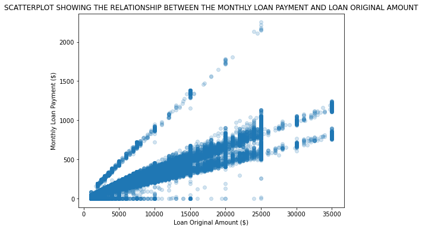

```python
# lets make a scatter plot of MonthlyLoanPayment vs. LoanOriginalAmount

plt.figure(figsize = [8, 6])
plt.scatter(data = df_loan, y = 'MonthlyLoanPayment', x = 'LoanOriginalAmount', alpha = 2/10)
plt.xlabel('Loan Original Amount ($)')
plt.ylabel('Monthly Loan Payment ($)')
plt.title('SCATTERPLOT SHOWING THE RELATIONSHIP BETWEEN THE MONTHLY LOAN PAYMENT AND LOAN ORIGINAL AMOUNT')
plt.show()
```

This plot comprising of all the data points shows a positive correlation between the MonthlyLoanPayment and LoanOriginalAmount. We can thus say that as the Loan Original Amount increases, a corresponding increase in the Monthly Loan Payment is observed.

### Talk about some of the relationships you observed in this part of the investigation. How did the feature(s) of interest vary with other features in the dataset?

MonthlyLoanPayment had a high amount of correlation with the LoanOriginalAmount. I had expected to see a bit of correlation between the MonthlyLoanPayment and the BorrowerAPR, but surprisingly they were negatively correlated. Also, I had some assumptions that the MonthlyLoanPayment would be influenced by strongly by the StatedMonthlyIncome (i.e A higher Monthly Income would attract a higher Monthly Loan Payment - Positive correlation) but a weak correlation was seen.

### Did you observe any interesting relationships between the other features (not the main feature(s) of interest)?

I had expected a positive correlation between the LoanOriginalAmount and the BorrowerAPR but instead a negative correlation was observed. Also, there was a small interaction in the categorical Loan variables.

## Multivariate Exploration

I want to use this part of the analysis to explore how the categorical variables (IncomeRange and Term) play into the relationship between Monthly Loan Payment and loan original amount.

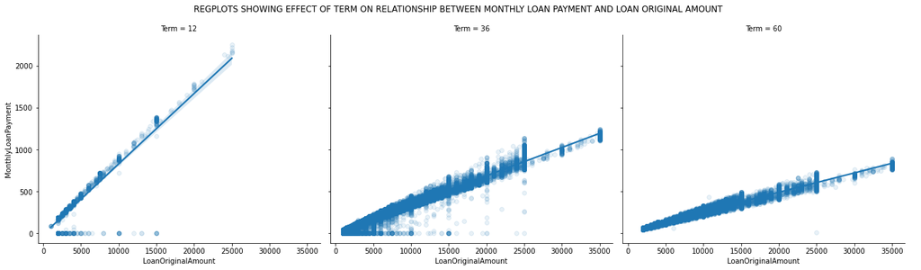

```python
# Term effect on relationship of Monthly payment and loan amount
g=sns.FacetGrid(data=df_loan, aspect=1.2, height=5, col='Term', col_wrap=3)
g.map(sns.regplot, 'LoanOriginalAmount', 'MonthlyLoanPayment', x_jitter=0.04, scatter_kws={'alpha':0.1});
g.add_legend();
g.fig.suptitle("REGPLOTS SHOWING EFFECT OF TERM ON RELATIONSHIP BETWEEN MONTHLY LOAN PAYMENT AND LOAN ORIGINAL AMOUNT", y=1.05);
```

This plot shows that as the term increases there seems to be a decrease in the Monthly Loan Payment and an increase in the Loan Original Amount. Although a positive correlation can be observed throughout.

[figure not shown]

```python
# IncomeRange effect on relationship of Monthly payment and loan amount
g=sns.FacetGrid(data=df_loan, aspect=1.1, height=5, col='IncomeRange', col_wrap=3)
g.map(sns.regplot, 'LoanOriginalAmount', 'MonthlyLoanPayment', x_jitter=0.04, scatter_kws={'alpha':0.1});
g.add_legend();
g.fig.suptitle("REGPLOTS SHOWING EFFECT OF INCOME RANGE ON RELATIONSHIP BETWEEN MONTHLY LOAN PAYMENT AND LOAN ORIGINAL AMOUNT", y=1.05);
```

Income Range doesn't seem to have much effect on the relationship between Monthly Loan Payment and Loan Original Amount.

### Were there any interesting or surprising interactions between features?

I didn't notice any special interactions among the features worth drawing much attention to.

## Conclusions

From the analysis performed above, It was seen that the LoanOriginalAmount has an effect on the MonthlyLoanPayment (positive correlation - an increase in LoanOriginalAmount saw an increase in the MonthlyLoanPayment). Also, further investigation revealed that the Term of the Loan affected that relationship (the longer the Term, the lower the MonthlyLoanPayment).